# Basic data visualization with ggplot2

### Position

The `position` argument of a geom describes the positions of the objects produced. Most of the time this is pretty straightforward, but there can be times when it is helpful (or unhelpful) to customize `position`.

#### Jittering data ([Jittering data video](https://youtu.be/Rv3oNQQIKIw))

Sometimes, data values/information overlap, which makes interpreting the plot more difficult. In that case, it can be useful to “jitter” the data so that the values/information are not overlapping. The data are not technically as accurate, but the large-scale distribution of the data is easier to interpret.

The `Galton` data set in the **HistData** package (Friendly 2021) includes 928 observations of 2 variales. The variables are:

- `parent`: a `numeric` variable indicating the average height of a child’s mother and father (in).
- `child`: a `numeric` variable indicating the height of each child (in).

Unfortunately, the rounding the data values leads to overplotting. Below, we load the `Galton` data and create a scatter plot of child height versus parents’ average height.

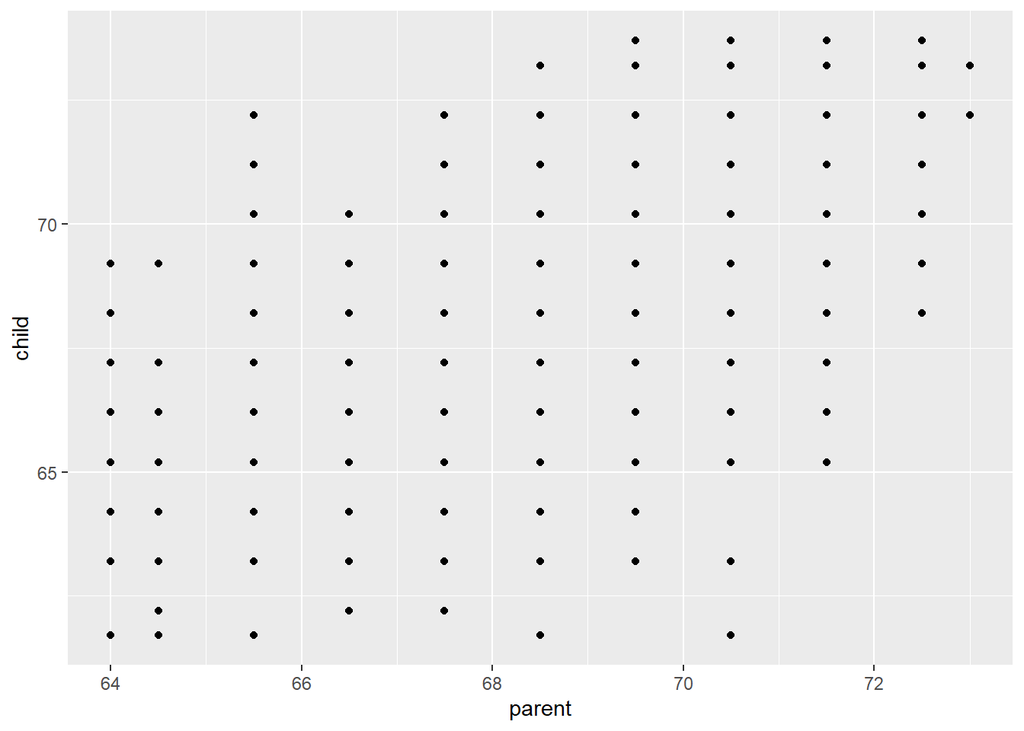

```r
data(Galton, package = "HistData")
ggplot(Galton) + geom_point(aes(x = parent, y = child))
```

There is a lot of overplotting in this graphic. We use the `position` argument to `jitter` the data to make the overall distribution clearer. There’s not a lot of information gain from jittering the data in this particular example, but we can see that there are more observations in the central part of the plot.

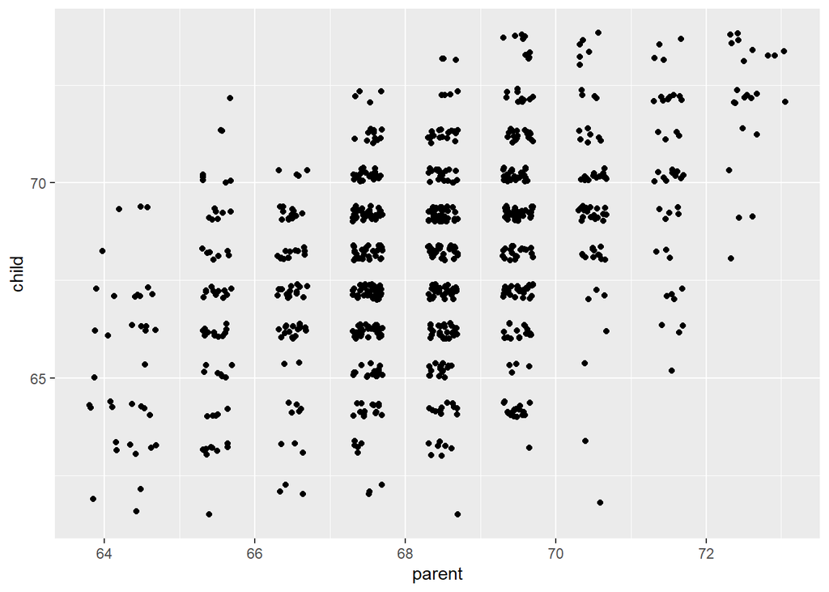

```r
ggplot(Galton) + geom_point(aes(x = parent, y = child), position = "jitter")
```

#### Stacking, filling, and dodging ([Stacking, filling, and dodging video](https://youtu.be/q1tTRuReq7w))

I was tempted to title this section, “plots that make me emotional” because several of the graphics below cause me to go through a range of mostly unpleasant emotions when I view them.

In this section, we’ll see how `stack`, `fill`, and `dodge` can be used in the `position` argument. While these examples demonstrate their use, some of the results are an absolute mess. I will conclude with alternative recommendations.

When creating a bar chart, a `factor` variable is mapped to the `x` aesthetic. If a different `factor` variable is mapped to the `fill` aesthetic, then **ggplot2** will `stack` the bars for the `fill` variable inside the bars for the `x` variable. Consider the bar chart below in which we “stack” penguin `sex` within the bars for the different species.

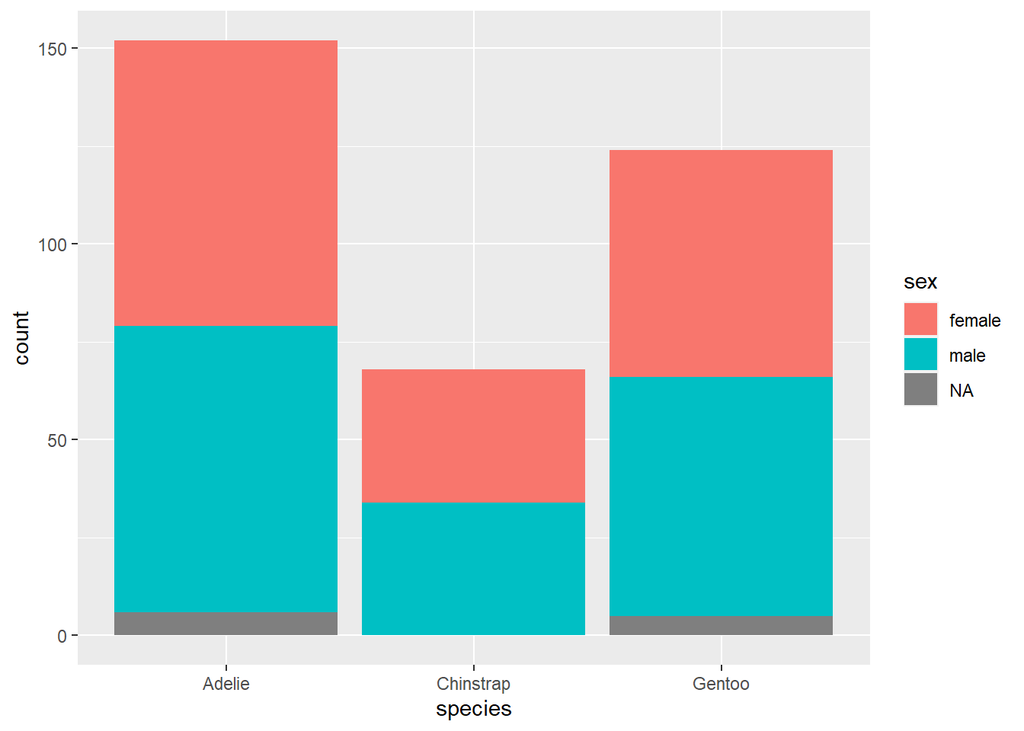

```r
ggplot(penguins) + geom_bar(aes(x = species, fill = sex))
```

If you compare this bar chart with the original one that doesn’t fill by `sex`, the bar height is identical. However, within each species, we `fill` the bars to show the number of penguins with each level of `sex`.

This plot is difficult to interpret. It takes a lot of mental energy to compute approximately how many male, female, and `NA` observations there are within each species. While the updated bar chart compactly provides a lot of information, it doesn’t facilitate easy interpretation.

If we wanted to compare the proportion of male, female, and `NA` penguins in each species, we can change the `position` argument to `fill`. In that case, the bars within each level of `species` will be scaled to one, directly facilitating comparisons between the colors within each bar.

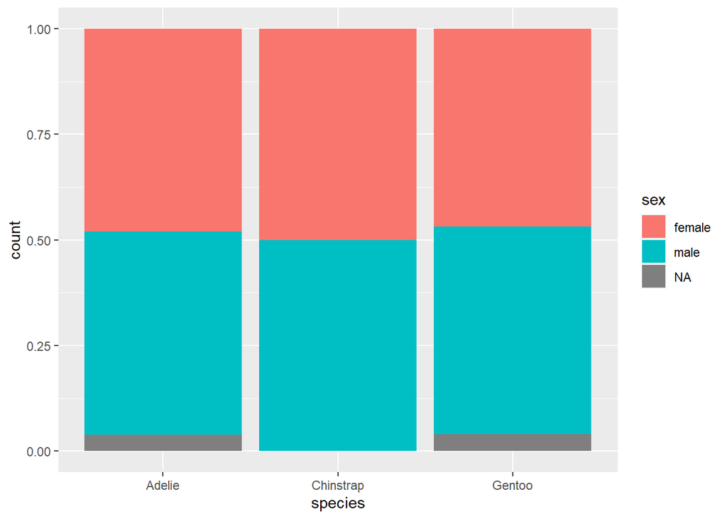

```r
ggplot(penguins) + geom_bar(aes(x = species, fill = sex), position = "fill")
```

I still consider this a poor display of the data, but we can see that the proportion of males is close to 50% for all species.

Lastly, if we don’t want to `stack` or `fill` the bars, we can have them `dodge` each other. In that case, the overlapping bars will “dodge” each other and sit next to each other in the plot.

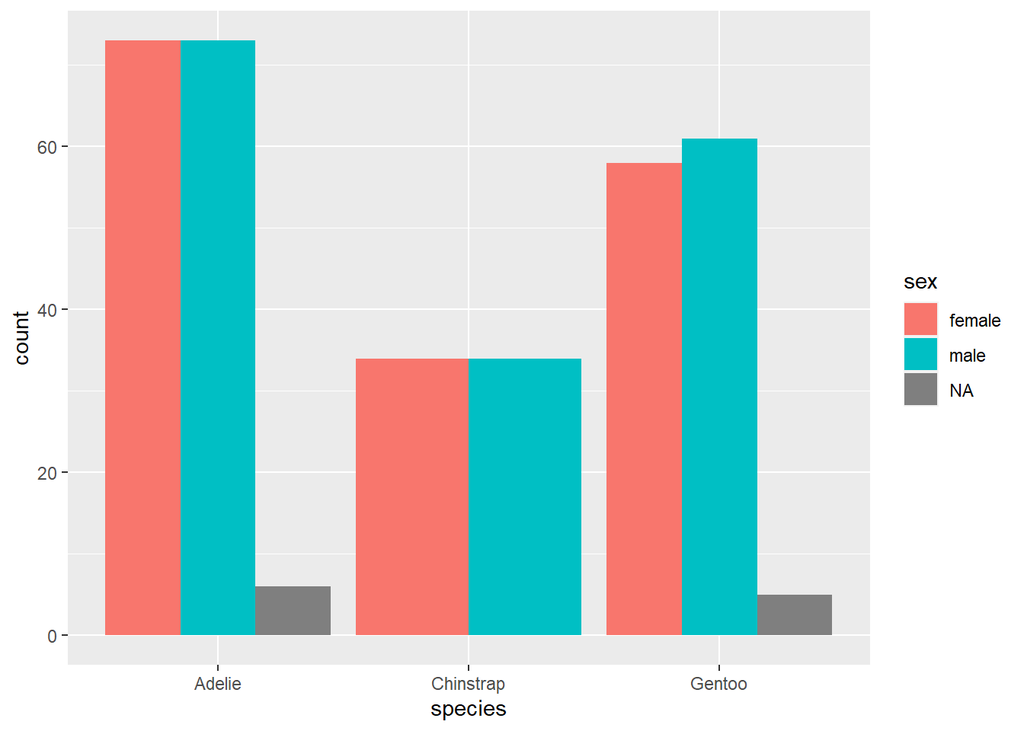

```r
ggplot(penguins) + geom_bar(aes(x = species, fill = sex), position = "dodge")
```

If you want to compare the number of penguins with each `sex` within each `species`, this graphic isn’t too bad. However, the bars representing male penguins (or alternatively, female penguins) are spread out and more difficult to compare directly because of the other bars between them.

While the above charts provide a fair amount of information compactly, to facilitate ease of interpretation we should construct our graphics to highlight the characteristic of importance.

e.g., If we want to compare the counts of each penguin `species` within each `sex`, it would be better to facet the data by `sex` and display the count of each species.

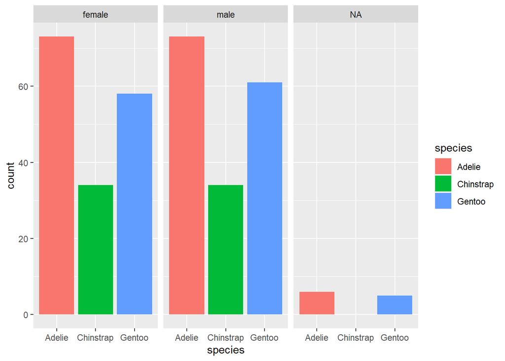

```r
ggplot(penguins) + geom_bar(aes(x = species, fill = species)) + facet_wrap(~sex)
```

Alternatively, if we want to highlight the composition of `sex` within each `species`, then I recommend creating a bar chart of `sex` while facetting by `species`. This plot is quite similar to the “dodge” plot above, but provides further distinction between the charts for each species.

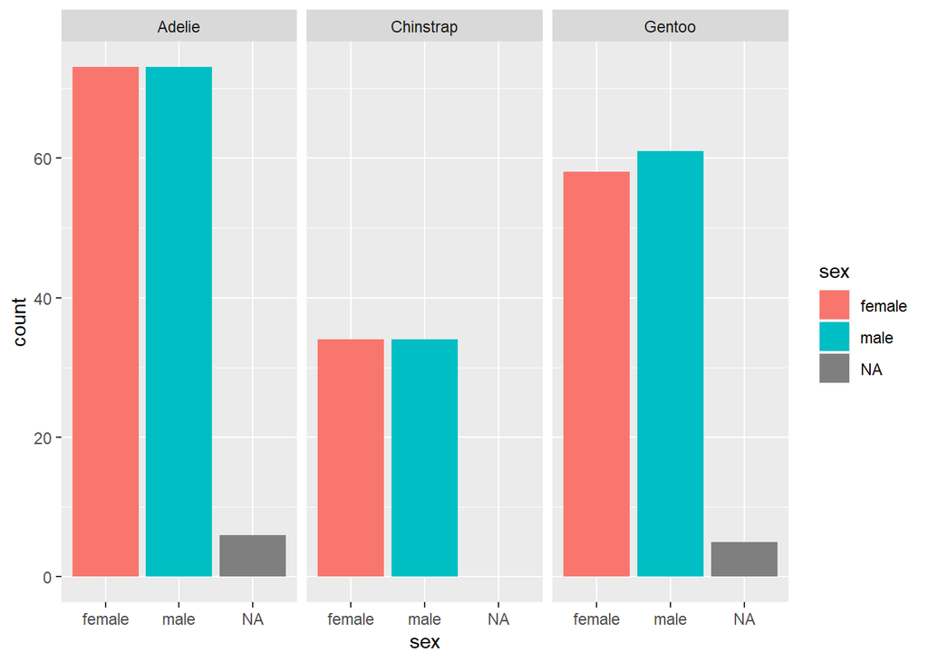

```r
ggplot(penguins) + geom_bar(aes(x = sex, fill = sex)) + facet_wrap(~species)
```

The examples above are shown for factor variables with only three levels of each factor, and you may think I’m overreacting (and perhaps I am). However, the issues mentioned above are magnified when our `factor` variables have many levels. To illustrate this point, I present “stack” and “dodge” bar charts of the `diamonds` data in the **ggplot2** package, in which we compare the `cut` and `clarity` of diamonds. Each variable has at least 5 levels. The large number of levels for the `cut` and `clarity` variables make it difficult to quickly interpret the relationship between the two variables. The **patchwork** package is used to combine the two charts into a single graphic. (We also rotate the x-axis labels 90 degrees so they don’t overlap each other). How easy is it for you to interpret the information below?

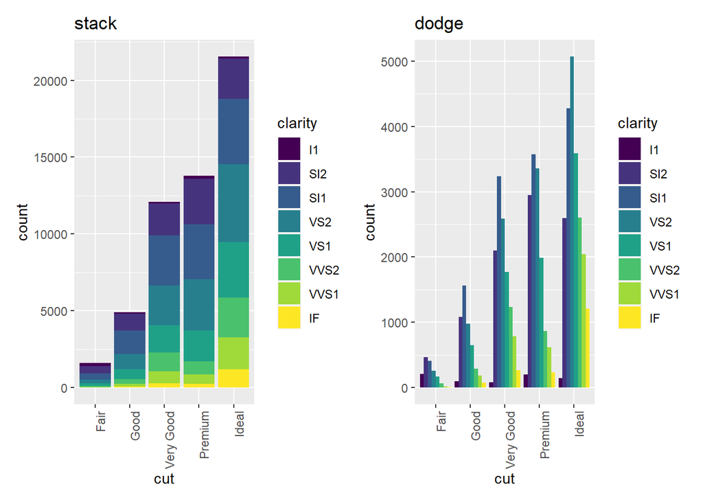

```r
ggp_stack <- ggplot(diamonds) + geom_bar(aes(x = cut, fill = clarity)) + ggtitle("stack") +
    theme(axis.text.x = element_text(angle = 90, hjust = 1))
ggp_dodge <- ggplot(diamonds) + geom_bar(aes(x = cut, fill = clarity), position = "dodge") +
    ggtitle("dodge") + theme(axis.text.x = element_text(angle = 90, hjust = 1))
ggp_stack + ggp_dodge
```

### Coordinate Systems ([Flipping coordinates video](https://youtu.be/naQPwZxkb2M))

A coordinate system is used to define the position of coordinates relative to one another. By default, **ggplot2** uses the Cartesian coordinate system (https://en.wikipedia.org/wiki/Cartesian_coordinate_system), which treats coordinates as points on a flat plane, which is how humans tend to think about coordinates in relationship to one another.

Other coordinates systems are commonly used for maps because points are actually on an ellipsoidal object (the earth!), which complicates their relationship.

We do not discuss coordinate systems in detail here. The only coordinate system I want to mentioned is the “flipped” coordinate system (`coord_flip`), which flips the x and y axes. This is useful for rotating objects in a plot. Consider the boxplots below.

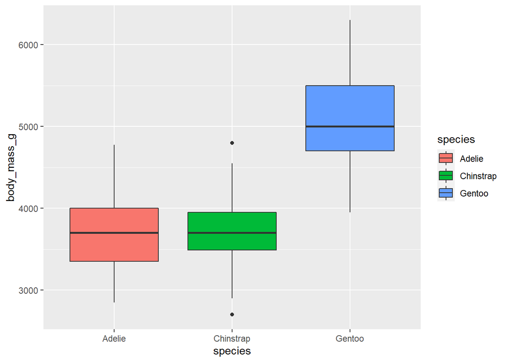

```r
ggplot(penguins) + geom_boxplot(aes(x = species, y = body_mass_g, fill = species))
```

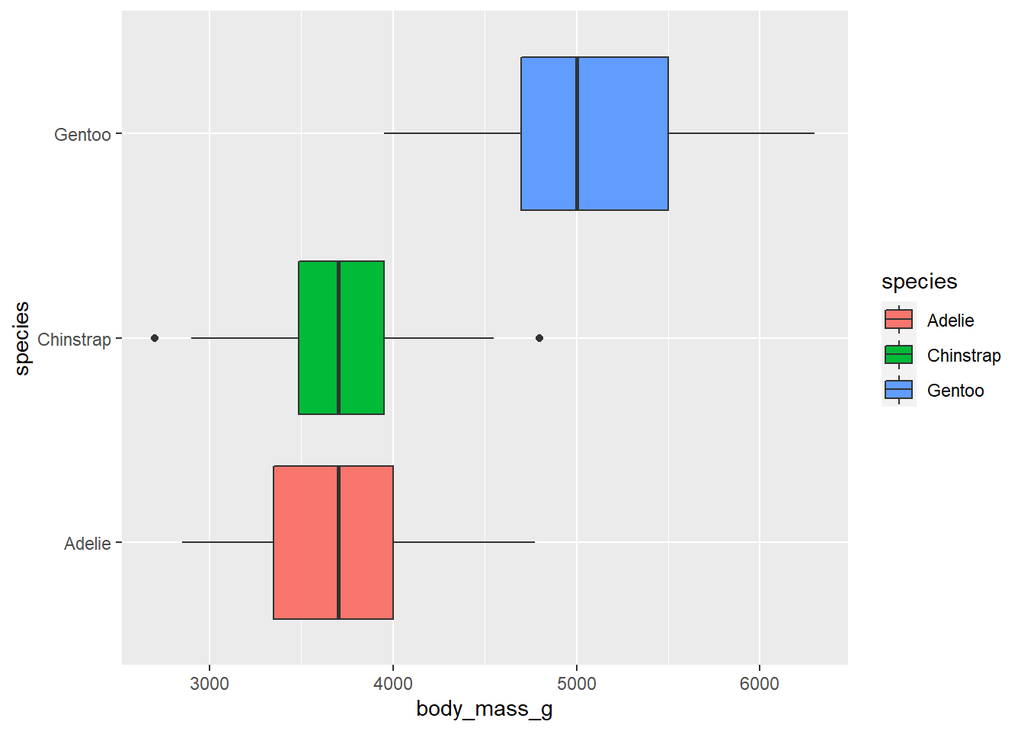

```r
ggplot(penguins) + geom_boxplot(aes(x = species, y = body_mass_g, fill = species)) +
    coord_flip()
```

## References

Becker, R. A., W. S. Cleveland, and M. J. Shyu. 1996. “The Visual Design and Control of Trellis Display.” *Journal of Computational and Graphical Statistics* 5 (2): 123–55.

Friendly, Michael. 2021. *HistData: Data Sets from the History of Statistics and Data Visualization*. https://CRAN.R-project.org/package=HistData.

Gorman, Kristen B., Tony D. Williams, and William R. Fraser. 2014. “Ecological Sexual Dimorphism and Environmental Variability Within a Community of Antarctic Penguins (Genus Pygoscelis).” *PLOS ONE* 9 (3): 1–14. https://doi.org/10.1371/journal.pone.0090081.

Horst, Allison, Alison Hill, and Kristen Gorman. 2020. *Palmerpenguins: Palmer Archipelago (Antarctica) Penguin Data*. https://CRAN.R-project.org/package=palmerpenguins.

Pedersen, Thomas Lin. 2022. *Patchwork: The Composer of Plots*. https://CRAN.R-project.org/package=patchwork.

Wickham, Hadley. 2016. *Ggplot2: Elegant Graphics for Data Analysis*. Springer-Verlag New York. https://ggplot2.tidyverse.org.

Wickham, Hadley, and Garrett Grolemund. 2017. *R for Data Science*. O’Reilly Media, Inc.

Wilkinson, Leland. 2005. *The Grammar of Graphics (Statistics and Computing)*. Berlin, Heidelberg: Springer-Verlag.